# Final Lab

```python
%matplotlib inline
import numpy as np
import math
import matplotlib
import matplotlib.pyplot as plt
import scipy
from scipy import stats
import pickle
plt.rcParams['figure.figsize'] = (15,10)

infile = open ("E:/EECS/PHYS434/Project/higgs_100000_pt_250_500.pkl",'rb')
higgs = pickle.load(infile)

infile = open ("E:/EECS/PHYS434/Project/qcd_100000_pt_250_500.pkl",'rb')
qcd = pickle.load(infile)
```

## Mass

We first start with the mass feature. Below is the stacked histogram plot for both the Higgs and QCD data normalized to their respective expected N values.

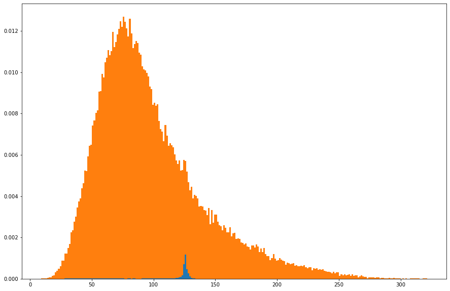

```
Given the expected yield, the significance resulting from Poisson statistics is 0.7112259282313185
N_Higgs/sqrt(N_QCD) for the low pT data set is 0.7071067811865475
```

```python
higgs_mean = np.mean(higgs['mass'])
qcd_mean = np.mean(qcd['mass'])
stacked = [higgs['mass'],qcd['mass']]
stacked_weight = [np.ones(100000)*100,np.ones(100000)*20000]

plt.hist(stacked,250,stacked=True,density=True,weights=stacked_weight)
plt.show()
poiSig = stats.norm.ppf(stats.poisson.cdf(20100,20000))
print('Given the expected yield, the significance resulting from Poisson statistics is ' + str(poiSig))
print('N_Higgs/sqrt(N_QCD) for the low pT data set is ' + str(100/math.sqrt(20000)))
```

Using Poisson statistics, I found the expected significance, and compared that to the N_Higgs/sqrt(N_QCD) value. It's quite low, but that's too be expected as N_QCD >> N_Higgs. The goal is to perform cuts in the data to find a particular region where N_Higgs/N_QCD is higher to optimize the significance. For the rest of the features, I will first plot the stacked and normalized histogram of the entire distribution, and follow it up with the distribution of the optimal cut, i.e. had the highest significance than the other cuts. The Higgs data will be blue color, and the QCD orange.

```python
def sig(feature, cut):
    dist = []
    totalArea = 0
    for i in range(100000):
        if cut:
            if higgs[feature][i] >= cut[0] and higgs[feature][i] < cut[1]:
                dist.append([higgs[feature][i], 'h'])
                totalArea += 100/20100
            if qcd[feature][i] >= cut[0] and qcd[feature][i] < cut[1]:
                dist.append([qcd[feature][i], 'q'])
                totalArea += 20000/20100
        else:
            dist.append([higgs[feature][i], 'h'])
            dist.append([qcd[feature][i], 'q'])
            totalArea += 1
    dist.sort()
    searchArea = 0
    for i in range(len(dist)):
        weighted = 0
        if dist[i][1] == 'h':
            weighted = 100/20100
        else:
            weighted = 20000/20100
        searchArea += weighted/totalArea
    counts = [0, 0]
    for i in range(len(dist)):
        if dist[i][1] == 'h':
            counts[0] += 100/20100
        else:
            counts[1] += 20000/20100
    return [i * 20100/100000 for i in counts]
```

```python
def makeCuts(start,end,step,feature):
    cut_results = []
    for i in range(int(start*10000),int(end*10000),int(step*10000)):
        cut = [i/10000, (i/10000)+step]
        counts = sig(feature, cut)
        cut_results.append([counts, (counts[0]/math.sqrt(counts[1]))])
    best_cut = 0
    test = 0
    for i in range(len(cut_results)):
        if cut_results[i][1] > test:
            test = cut_results[i][1]
            best_cut = i
    cut_results[best_cut].append(best_cut)
    return cut_results[best_cut]
```

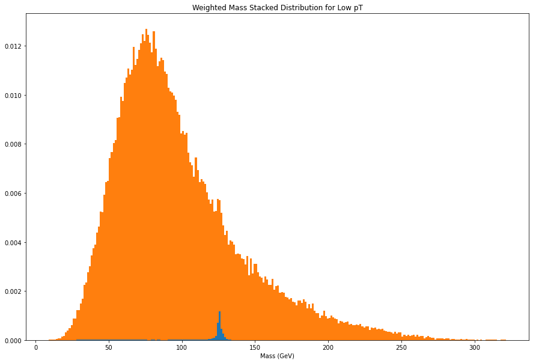

```
N_Higgs = 100.0000000001471
N_QCD = 19999.99999998956
N_Higgs/sqrt(N_QCD) = 0.7071067811877723
Poisson Significance = 0.7041666186913429
```

```python
counts = sig('mass',[])
poiSig = stats.norm.ppf(stats.poisson.cdf(np.sum(counts),counts[1]))
plt.hist(stacked,250,stacked=True,density=True,weights=stacked_weight)
plt.title('Weighted Mass Stacked Distribution for Low pT')
plt.xlabel('Mass (GeV)')
plt.show()
print('N_Higgs = ' + str(counts[0]))
print('N_QCD = ' + str(counts[1]))
print('N_Higgs/sqrt(N_QCD) = ' + str(counts[0]/math.sqrt(counts[1])))
print('Poisson Significance = ' + str(poiSig))
```

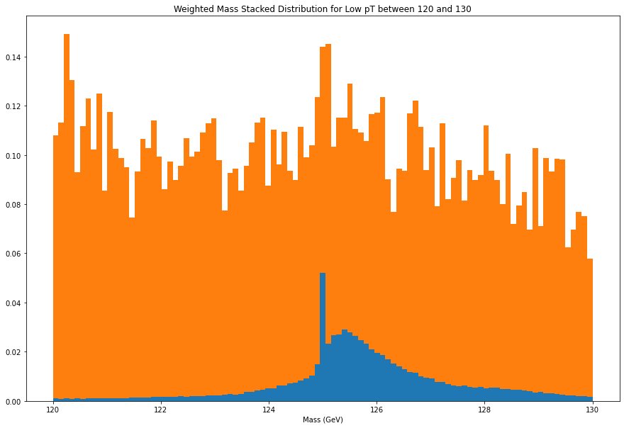

```
N_Higgs = 75.84700000009492
N_QCD = 980.2000000000202
N_Higgs/sqrt(N_QCD) = 2.4225963501824745
Poisson Significance = 2.411688648925278
```

```python
result = makeCuts(100,150,10,'mass')
limit = 100+(10*result[2])
x = np.linspace(limit,limit+10,100)
plt.hist(stacked,x,stacked=True,density=True,weights=stacked_weight)
plt.title('Weighted Mass Stacked Distribution for Low pT between ' + str(limit) + ' and ' + str(limit+10))
plt.xlabel('Mass (GeV)')
plt.show()
poiSig = stats.norm.ppf(stats.poisson.cdf(np.sum(result[0]),result[0][1]))
print('N_Higgs = ' + str(result[0][0]))
print('N_QCD = ' + str(result[0][1]))
print('N_Higgs/sqrt(N_QCD) = ' + str(result[0][0]/math.sqrt(result[0][1])))
print('Poisson Significance = ' + str(poiSig))
```

## Tranverse Momentum

Before starting the lab, I had high expectations regarding pT to be one of the more optimal features for this endeavour. However, I changed my mind after normalizing and stacking the two distributions onto each other. The significance increase was quite negligable.

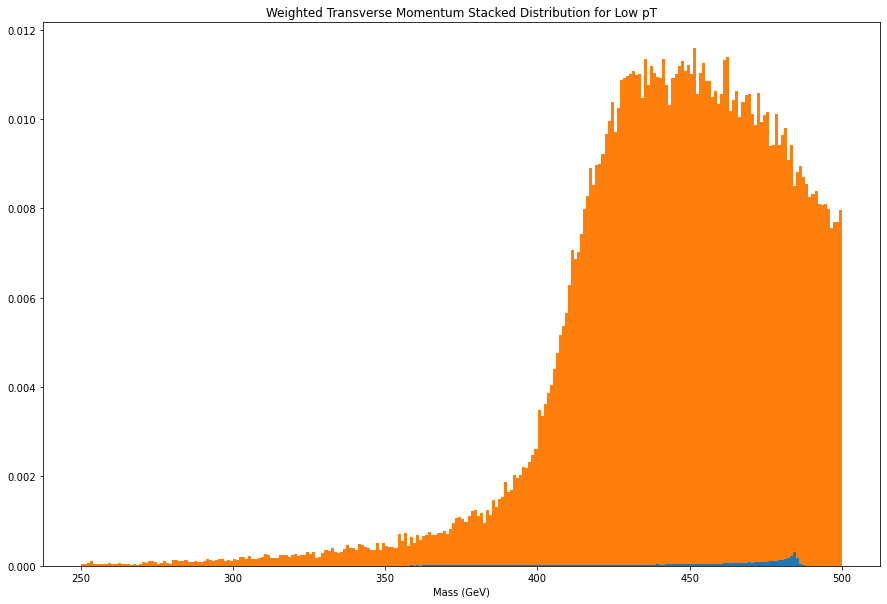

```
N_Higgs = 100.0000000001471
N_QCD = 19999.99999998956
N_Higgs/sqrt(N_QCD) = 0.7071067811877723
Poisson Significance = 0.7041666186913429
```

```python
counts = sig('pt',[])
stacked = [higgs['pt'],qcd['pt']]
poiSig = stats.norm.ppf(stats.poisson.cdf(np.sum(counts),counts[1]))
plt.hist(stacked,250,stacked=True,density=True,weights=stacked_weight)
plt.title('Weighted Transverse Momentum Stacked Distribution for Low pT')
plt.xlabel('Mass (GeV)')
plt.show()
print('N_Higgs = ' + str(counts[0]))
print('N_QCD = ' + str(counts[1]))
print('N_Higgs/sqrt(N_QCD) = ' + str(counts[0]/math.sqrt(counts[1])))
print('Poisson Significance = ' + str(poiSig))
```

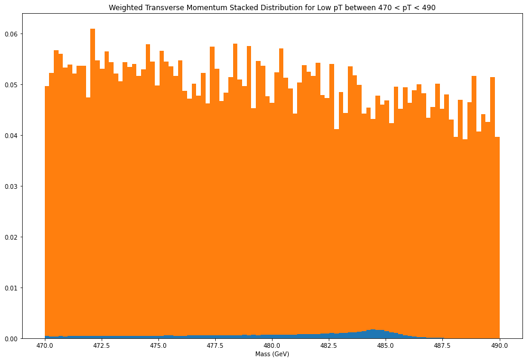

```
N_Higgs = 43.33600000002471
N_QCD = 3750.7999999990166
N_Higgs/sqrt(N_QCD) = 0.7075984434798901
Poisson Significance = 0.7148792187272387
```

```python
result = makeCuts(410,490,20,'pt')
limit = 410+(20*result[2])
x = np.linspace(limit,limit+20,100)
plt.hist(stacked,x,stacked=True,density=True,weights=stacked_weight)
plt.title('Weighted Transverse Momentum Stacked Distribution for Low pT between '
          + str(limit) + ' < pT < ' + str(limit+20))
plt.xlabel('Mass (GeV)')
plt.show()
poiSig = stats.norm.ppf(stats.poisson.cdf(np.sum(result[0]),result[0][1]))
print('N_Higgs = ' + str(result[0][0]))
print('N_QCD = ' + str(result[0][1]))
print('N_Higgs/sqrt(N_QCD) = ' + str(result[0][0]/math.sqrt(result[0][1])))
print('Poisson Significance = ' + str(poiSig))
```

## Pseudorapidity

Practically a Gaussian distribution, so unsurprisingly the optimal cut is centered around 0. The resulting significance is more or less the same as initial.

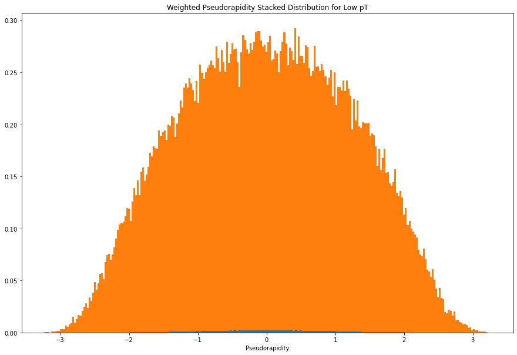

```
N_Higgs = 100.0000000001471
N_QCD = 19999.99999998956
N_Higgs/sqrt(N_QCD) = 0.7071067811877723
Poisson Significance = 0.7041666186913429
```

```python
counts = sig('eta',[])
stacked = [higgs['eta'],qcd['eta']]
poiSig = stats.norm.ppf(stats.poisson.cdf(np.sum(counts),counts[1]))
plt.hist(stacked,250,stacked=True,density=True,weights=stacked_weight)
plt.title('Weighted Pseudorapidity Stacked Distribution for Low pT')
plt.xlabel('Pseudorapidity')
plt.show()
print('N_Higgs = ' + str(counts[0]))
print('N_QCD = ' + str(counts[1]))
print('N_Higgs/sqrt(N_QCD) = ' + str(counts[0]/math.sqrt(counts[1])))
print('Poisson Significance = ' + str(poiSig))
```

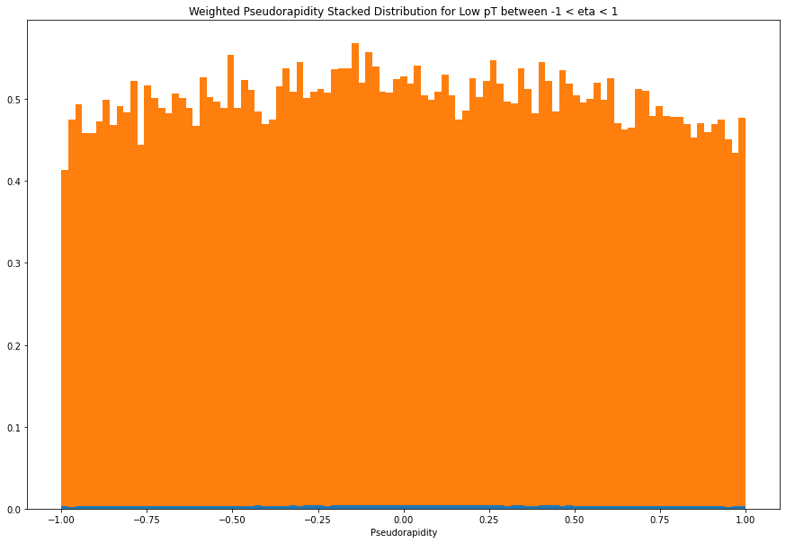

```
N_Higgs = 71.5760000000857
N_QCD = 10559.799999995053
N_Higgs/sqrt(N_QCD) = 0.6965296012977974
Poisson Significance = 0.6985689944619492
```

```python
result = makeCuts(-3,3,2,'eta')
limit = (-3)+(2*result[2])
x = np.linspace(limit,limit+2,100)
plt.hist(stacked,x,stacked=True,density=True,weights=stacked_weight)
plt.title('Weighted Pseudorapidity Stacked Distribution for Low pT between '
          + str(limit) + ' < eta < ' + str(limit+2))
plt.xlabel('Pseudorapidity')
plt.show()
poiSig = stats.norm.ppf(stats.poisson.cdf(np.sum(result[0]),result[0][1]))
print('N_Higgs = ' + str(result[0][0]))
print('N_QCD = ' + str(result[0][1]))
print('N_Higgs/sqrt(N_QCD) = ' + str(result[0][0]/math.sqrt(result[0][1])))
print('Poisson Significance = ' + str(poiSig))
```

## Azimuthal Angle

This distribution is basically uniform, so cuts will result in relatively same significances, therefore not worth to try.

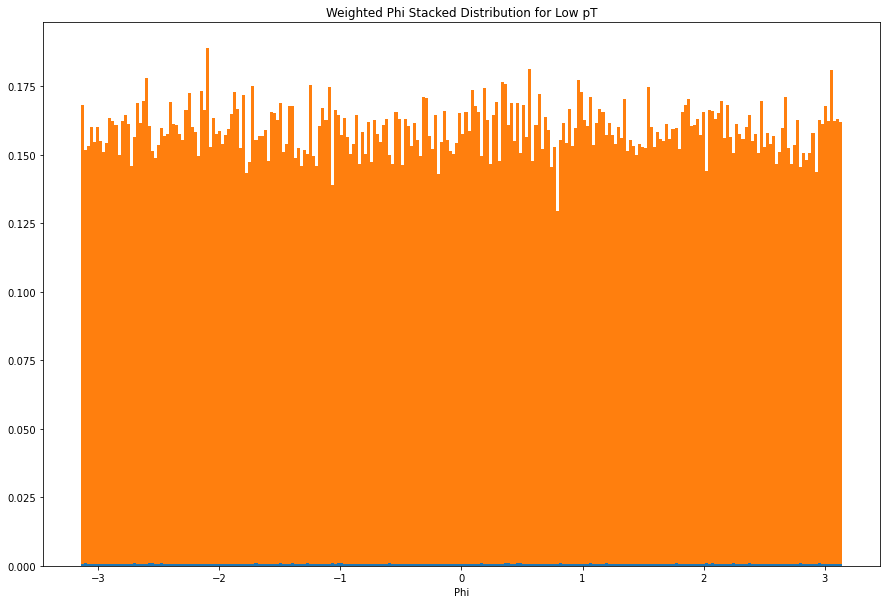

```
N_Higgs = 100.0000000001471
N_QCD = 19999.99999998956
N_Higgs/sqrt(N_QCD) = 0.7071067811877723
Poisson Significance = 0.7041666186913429
```

```python
counts = sig('phi',[])
stacked = [higgs['phi'],qcd['phi']]
poiSig = stats.norm.ppf(stats.poisson.cdf(np.sum(counts),counts[1]))
plt.hist(stacked,250,stacked=True,density=True,weights=stacked_weight)
plt.title('Weighted Phi Stacked Distribution for Low pT')
plt.xlabel('Phi')
plt.show()
print('N_Higgs = ' + str(counts[0]))
print('N_QCD = ' + str(counts[1]))
print('N_Higgs/sqrt(N_QCD) = ' + str(counts[0]/math.sqrt(counts[1])))
print('Poisson Significance = ' + str(poiSig))
```

## EE2

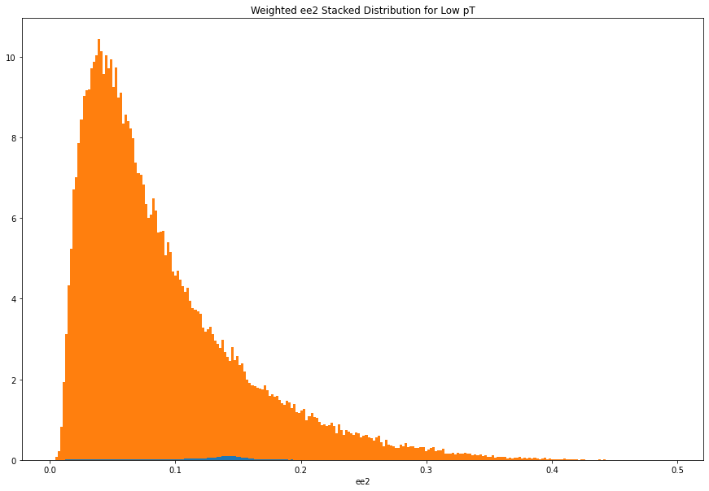

```
N_Higgs = 100.0000000001471
N_QCD = 19999.99999998956
N_Higgs/sqrt(N_QCD) = 0.7071067811877723
Poisson Significance = 0.7041666186913429
```

```python
counts = sig('ee2',[])
stacked = [higgs['ee2'],qcd['ee2']]
poiSig = stats.norm.ppf(stats.poisson.cdf(np.sum(counts),counts[1]))
plt.hist(stacked,250,stacked=True,density=True,weights=stacked_weight)
plt.title('Weighted ee2 Stacked Distribution for Low pT')
plt.xlabel('ee2')
plt.show()
print('N_Higgs = ' + str(counts[0]))
print('N_QCD = ' + str(counts[1]))
print('N_Higgs/sqrt(N_QCD) = ' + str(counts[0]/math.sqrt(counts[1])))
print('Poisson Significance = ' + str(poiSig))
```

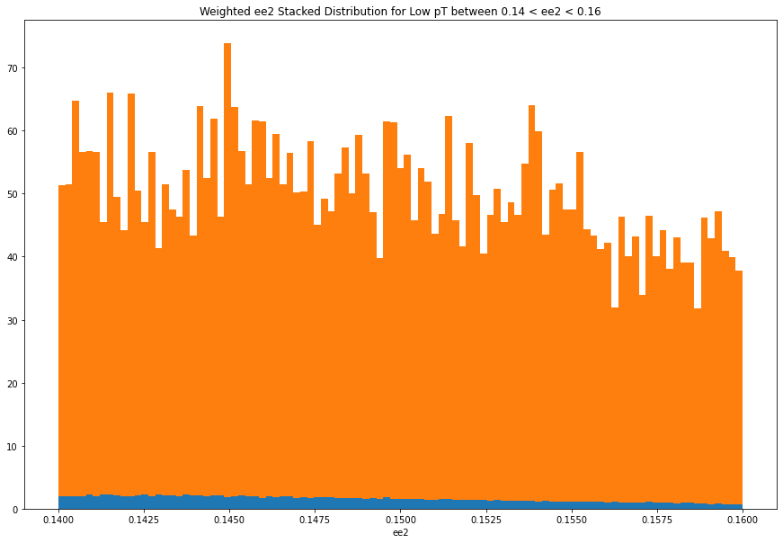

```
N_Higgs = 29.518999999994858
N_QCD = 931.4000000000038
N_Higgs/sqrt(N_QCD) = 0.967238387214886
Poisson Significance = 0.9540412999392596
```

```python
result = makeCuts(0.1,0.2,0.02,'ee2')
limit = (0.1)+(0.02*result[2])
x = np.linspace(limit,limit+0.02,100)
plt.hist(stacked,x,stacked=True,density=True,weights=stacked_weight)
plt.title('Weighted ee2 Stacked Distribution for Low pT between '
          + str(limit) + ' < ee2 < ' + str(limit+0.02))
plt.xlabel('ee2')
plt.show()
poiSig = stats.norm.ppf(stats.poisson.cdf(np.sum(result[0]),result[0][1]))
print('N_Higgs = ' + str(result[0][0]))
print('N_QCD = ' + str(result[0][1]))
print('N_Higgs/sqrt(N_QCD) = ' + str(result[0][0]/math.sqrt(result[0][1])))
print('Poisson Significance = ' + str(poiSig))
```

## EE3

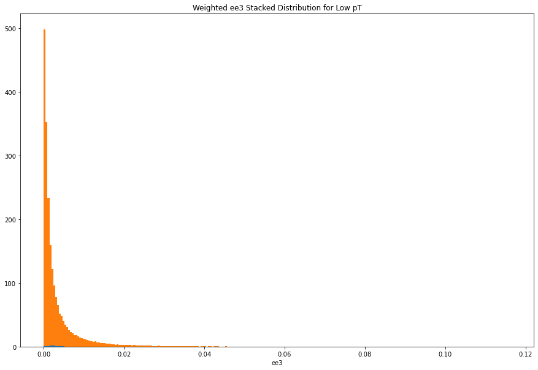

```
N_Higgs = 100.0000000001471
N_QCD = 19999.99999998956
N_Higgs/sqrt(N_QCD) = 0.7071067811877723
Poisson Significance = 0.7041666186913429
```

```python
counts = sig('ee3',[])
stacked = [higgs['ee3'],qcd['ee3']]
poiSig = stats.norm.ppf(stats.poisson.cdf(np.sum(counts),counts[1]))
plt.hist(stacked,250,stacked=True,density=True,weights=stacked_weight)
plt.title('Weighted ee3 Stacked Distribution for Low pT')
plt.xlabel('ee3')
plt.show()
print('N_Higgs = ' + str(counts[0]))
print('N_QCD = ' + str(counts[1]))
print('N_Higgs/sqrt(N_QCD) = ' + str(counts[0]/math.sqrt(counts[1])))
print('Poisson Significance = ' + str(poiSig))
```

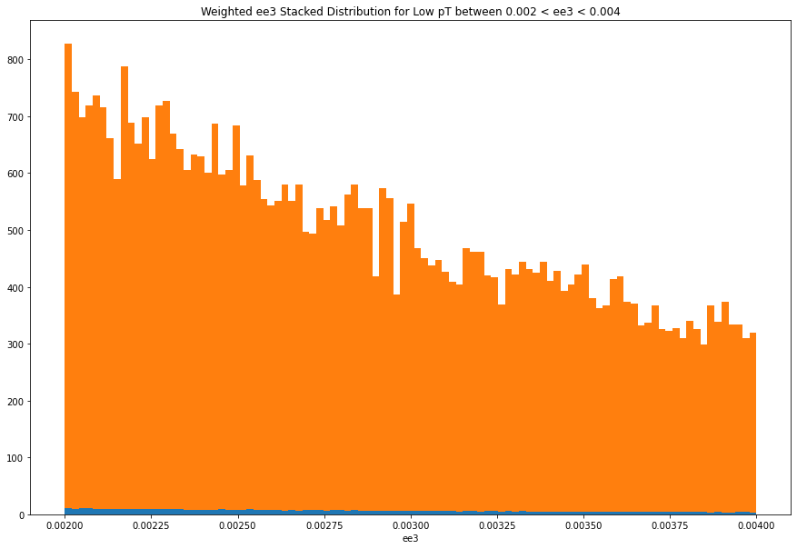

```
N_Higgs = 42.102000000022045
N_QCD = 3253.5999999993055
N_Higgs/sqrt(N_QCD) = 0.7381092487524296
Poisson Significance = 0.7359154399724546
```

```python
result = makeCuts(0,0.01,0.002,'ee3')
limit = (0)+(0.002*result[2])
x = np.linspace(limit,limit+0.002,100)
plt.hist(stacked,x,stacked=True,density=True,weights=stacked_weight)
plt.title('Weighted ee3 Stacked Distribution for Low pT between '
          + str(limit) + ' < ee3 < ' + str(limit+0.002))
plt.xlabel('ee3')
plt.show()
poiSig = stats.norm.ppf(stats.poisson.cdf(np.sum(result[0]),result[0][1]))
print('N_Higgs = ' + str(result[0][0]))
print('N_QCD = ' + str(result[0][1]))
print('N_Higgs/sqrt(N_QCD) = ' + str(result[0][0]/math.sqrt(result[0][1])))
print('Poisson Significance = ' + str(poiSig))
```

## D2

The D2 ratio was a strong characterization of 1-prong vs 2-prong jets. The 1-prong jets, which are usually background jets, dominate larger D2 ranges as expected, however the QCD data is skewed the same way as the Higgs did. The significance increase was notable.

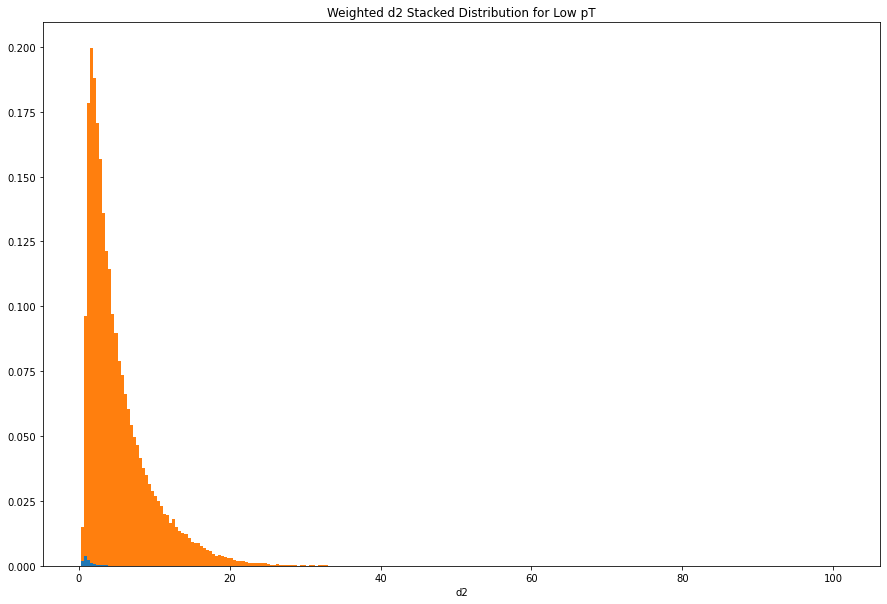

```
N_Higgs = 100.0000000001471
N_QCD = 19999.99999998956
N_Higgs/sqrt(N_QCD) = 0.7071067811877723
Poisson Significance = 0.7041666186913429
```

```python
feature = 'd2'
counts = sig(feature,[])
stacked = [higgs[feature],qcd[feature]]
poiSig = stats.norm.ppf(stats.poisson.cdf(np.sum(counts),counts[1]))
plt.hist(stacked,250,stacked=True,density=True,weights=stacked_weight)
plt.title('Weighted ' + feature + ' Stacked Distribution for Low pT')
plt.xlabel(feature)
plt.show()
print('N_Higgs = ' + str(counts[0]))
print('N_QCD = ' + str(counts[1]))
print('N_Higgs/sqrt(N_QCD) = ' + str(counts[0]/math.sqrt(counts[1])))
print('Poisson Significance = ' + str(poiSig))
```

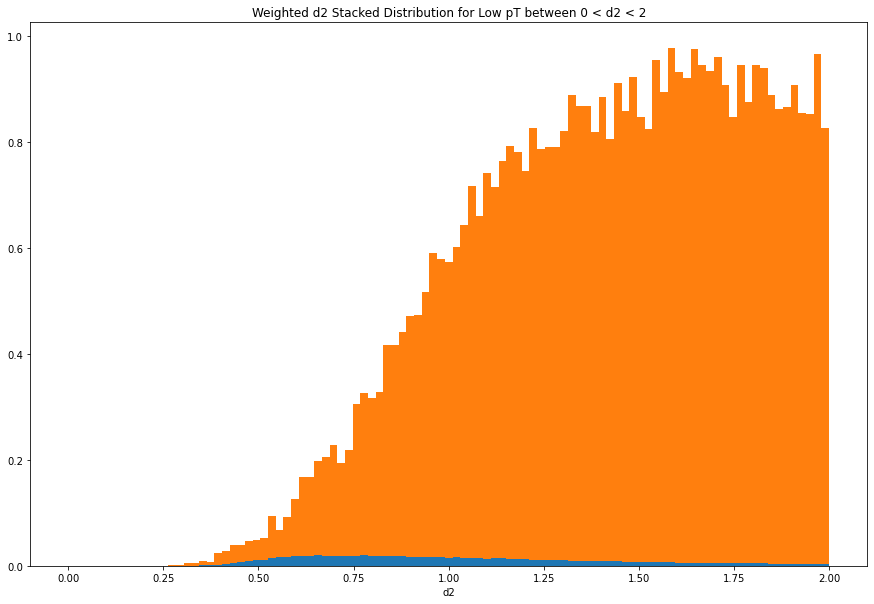

```
N_Higgs = 78.04000000009967
N_QCD = 4315.599999998688
N_Higgs/sqrt(N_QCD) = 1.187945915128196
Poisson Significance = 1.1848034215576368
```

```python
result = makeCuts(0,10,2,feature)
limit = (0)+(2*result[2])
x = np.linspace(limit,limit+2,100)
plt.hist(stacked,x,stacked=True,density=True,weights=stacked_weight)
plt.title('Weighted ' + feature + ' Stacked Distribution for Low pT between '
          + str(limit) + ' < ' + feature + ' < ' + str(limit+2))
plt.xlabel(feature)
plt.show()
poiSig = stats.norm.ppf(stats.poisson.cdf(np.sum(result[0]),result[0][1]))
print('N_Higgs = ' + str(result[0][0]))
print('N_QCD = ' + str(result[0][1]))
print('N_Higgs/sqrt(N_QCD) = ' + str(result[0][0]/math.sqrt(result[0][1])))
print('Poisson Significance = ' + str(poiSig))
```

## Angularity

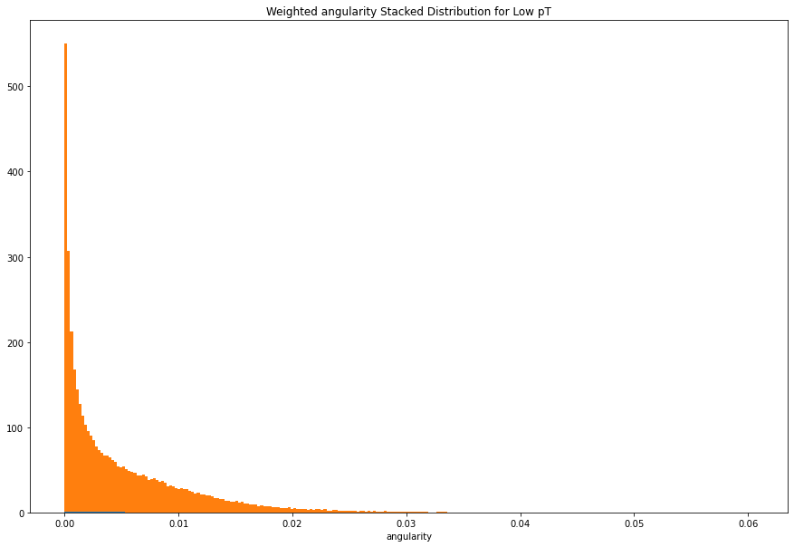

```
N_Higgs = 100.0000000001471
N_QCD = 19999.99999998956
N_Higgs/sqrt(N_QCD) = 0.7071067811877723
Poisson Significance = 0.7041666186913429
```

```python
feature = 'angularity'
counts = sig(feature,[])
stacked = [higgs[feature],qcd[feature]]
poiSig = stats.norm.ppf(stats.poisson.cdf(np.sum(counts),counts[1]))
plt.hist(stacked,250,stacked=True,density=True,weights=stacked_weight)
plt.title('Weighted ' + feature + ' Stacked Distribution for Low pT')
plt.xlabel(feature)
plt.show()
print('N_Higgs = ' + str(counts[0]))
print('N_QCD = ' + str(counts[1]))
print('N_Higgs/sqrt(N_QCD) = ' + str(counts[0]/math.sqrt(counts[1])))
print('Poisson Significance = ' + str(poiSig))
```

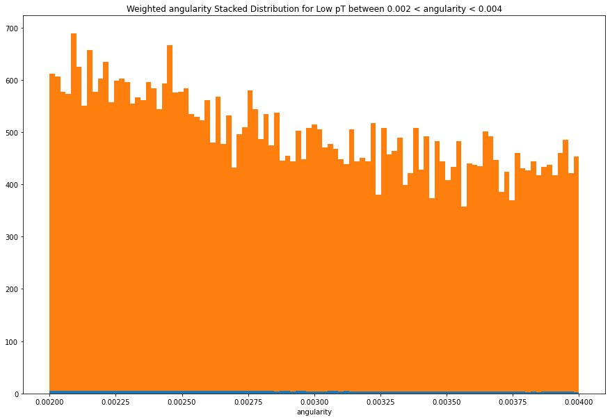

```
N_Higgs = 26.49499999998833
N_QCD = 3054.599999999422
N_Higgs/sqrt(N_QCD) = 0.4793875491168427
Poisson Significance = 0.4890149532651164
```

```python
result = makeCuts(0,0.01,0.002,feature)
limit = (0)+(0.002*result[2])
x = np.linspace(limit,limit+0.002,100)
plt.hist(stacked,x,stacked=True,density=True,weights=stacked_weight)
plt.title('Weighted ' + feature + ' Stacked Distribution for Low pT between '
          + str(limit) + ' < ' + feature + ' < ' + str(limit+0.002))
plt.xlabel(feature)
plt.show()
poiSig = stats.norm.ppf(stats.poisson.cdf(np.sum(result[0]),result[0][1]))
print('N_Higgs = ' + str(result[0][0]))
print('N_QCD = ' + str(result[0][1]))
print('N_Higgs/sqrt(N_QCD) = ' + str(result[0][0]/math.sqrt(result[0][1])))
print('Poisson Significance = ' + str(poiSig))
```

## T1 Subjetiness

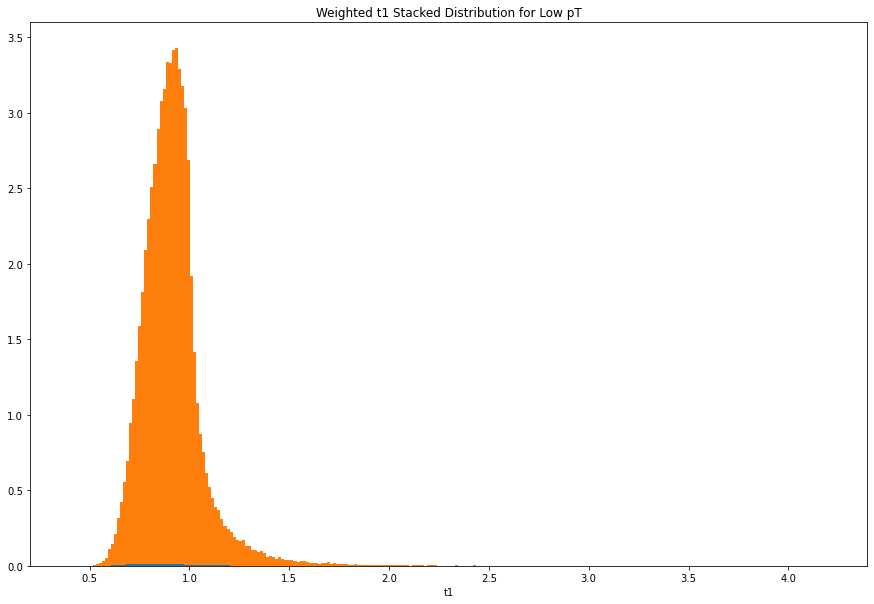

```
N_Higgs = 100.0000000001471
N_QCD = 19999.99999998956
N_Higgs/sqrt(N_QCD) = 0.7071067811877723
Poisson Significance = 0.7041666186913429
```

```python
feature = 't1'
counts = sig(feature,[])
stacked = [higgs[feature],qcd[feature]]
poiSig = stats.norm.ppf(stats.poisson.cdf(np.sum(counts),counts[1]))
plt.hist(stacked,250,stacked=True,density=True,weights=stacked_weight)
plt.title('Weighted ' + feature + ' Stacked Distribution for Low pT')
plt.xlabel(feature)
plt.show()
print('N_Higgs = ' + str(counts[0]))
print('N_QCD = ' + str(counts[1]))
print('N_Higgs/sqrt(N_QCD) = ' + str(counts[0]/math.sqrt(counts[1])))
print('Poisson Significance = ' + str(poiSig))
```

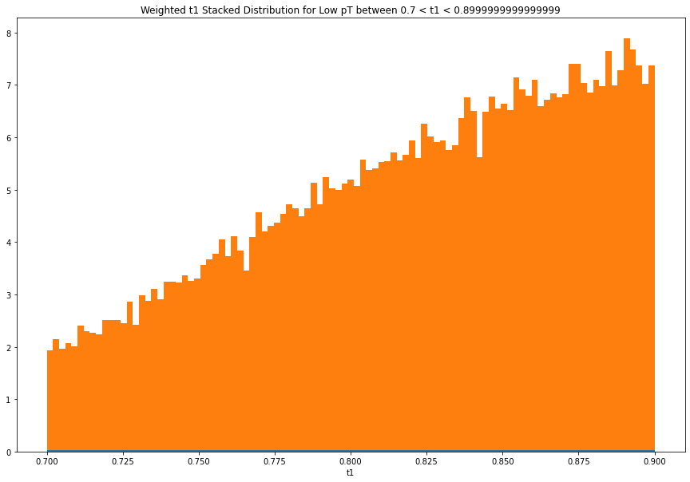

```
N_Higgs = 47.69400000003412
N_QCD = 9012.599999995955
N_Higgs/sqrt(N_QCD) = 0.5023873542648738
Poisson Significance = 0.5058653820086895
```

```python
result = makeCuts(0.5,1.5,0.2,feature)
limit = (0.5)+(0.2*result[2])
x = np.linspace(limit,limit+0.2,100)
plt.hist(stacked,x,stacked=True,density=True,weights=stacked_weight)
plt.title('Weighted ' + feature + ' Stacked Distribution for Low pT between '
          + str(limit) + ' < ' + feature + ' < ' + str(limit+0.2))
plt.xlabel(feature)
plt.show()
poiSig = stats.norm.ppf(stats.poisson.cdf(np.sum(result[0]),result[0][1]))
print('N_Higgs = ' + str(result[0][0]))
print('N_QCD = ' + str(result[0][1]))
print('N_Higgs/sqrt(N_QCD) = ' + str(result[0][0]/math.sqrt(result[0][1])))
print('Poisson Significance = ' + str(poiSig))
```

## T2 Subjetiness

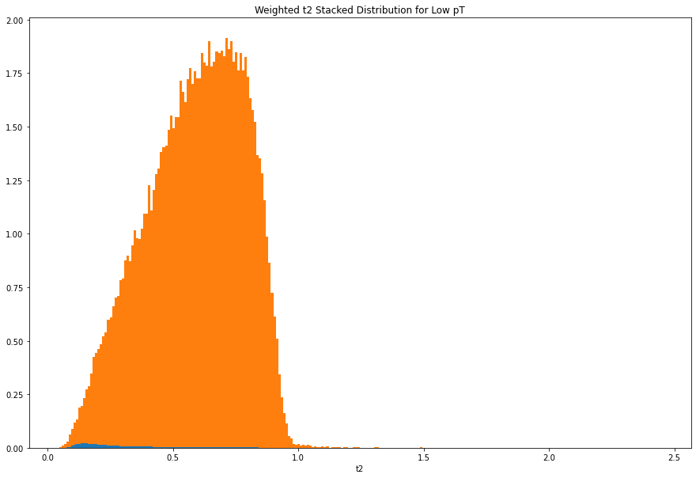

```
N_Higgs = 100.0000000001471
N_QCD = 19999.99999998956
N_Higgs/sqrt(N_QCD) = 0.7071067811877723
Poisson Significance = 0.7041666186913429
```

```python
feature = 't2'
counts = sig(feature,[])
stacked = [higgs[feature],qcd[feature]]
poiSig = stats.norm.ppf(stats.poisson.cdf(np.sum(counts),counts[1]))
plt.hist(stacked,250,stacked=True,density=True,weights=stacked_weight)
plt.title('Weighted ' + feature + ' Stacked Distribution for Low pT')
plt.xlabel(feature)
plt.show()
print('N_Higgs = ' + str(counts[0]))
print('N_QCD = ' + str(counts[1]))
print('N_Higgs/sqrt(N_QCD) = ' + str(counts[0]/math.sqrt(counts[1])))
print('Poisson Significance = ' + str(poiSig))
```

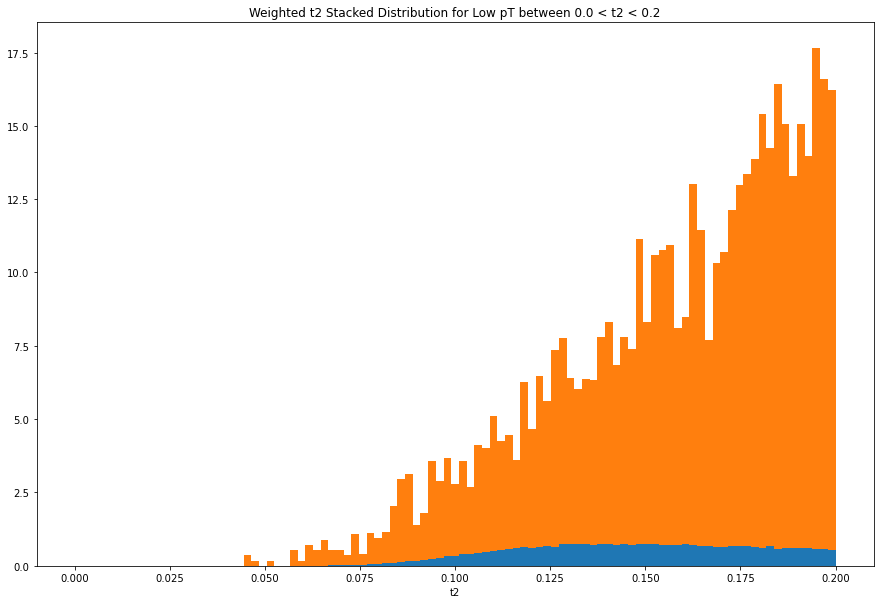

```
N_Higgs = 38.35800000001396
N_QCD = 523.6000000000055
N_Higgs/sqrt(N_QCD) = 1.6763169480486773
Poisson Significance = 1.644099530626987
```

```python
result = makeCuts(0,0.6,0.2,feature)
limit = (0)+(0.2*result[2])
x = np.linspace(limit,limit+0.2,100)
plt.hist(stacked,x,stacked=True,density=True,weights=stacked_weight)
plt.title('Weighted ' + feature + ' Stacked Distribution for Low pT between '
          + str(limit) + ' < ' + feature + ' < ' + str(limit+0.2))
plt.xlabel(feature)
plt.show()
poiSig = stats.norm.ppf(stats.poisson.cdf(np.sum(result[0]),result[0][1]))
print('N_Higgs = ' + str(result[0][0]))
print('N_QCD = ' + str(result[0][1]))
print('N_Higgs/sqrt(N_QCD) = ' + str(result[0][0]/math.sqrt(result[0][1])))
print('Poisson Significance = ' + str(poiSig))
```

## T3 Subjetiness

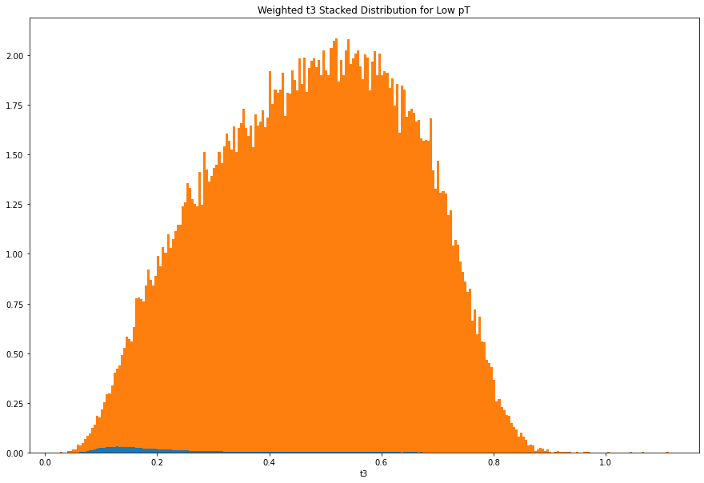

```
N_Higgs = 100.0000000001471
N_QCD = 19999.99999998956
N_Higgs/sqrt(N_QCD) = 0.7071067811877723
Poisson Significance = 0.7041666186913429
```

```python
feature = 't3'
counts = sig(feature,[])
stacked = [higgs[feature],qcd[feature]]
poiSig = stats.norm.ppf(stats.poisson.cdf(np.sum(counts),counts[1]))
plt.hist(stacked,250,stacked=True,density=True,weights=stacked_weight)
plt.title('Weighted ' + feature + ' Stacked Distribution for Low pT')
plt.xlabel(feature)
plt.show()
print('N_Higgs = ' + str(counts[0]))
print('N_QCD = ' + str(counts[1]))
print('N_Higgs/sqrt(N_QCD) = ' + str(counts[0]/math.sqrt(counts[1])))
print('Poisson Significance = ' + str(poiSig))
```

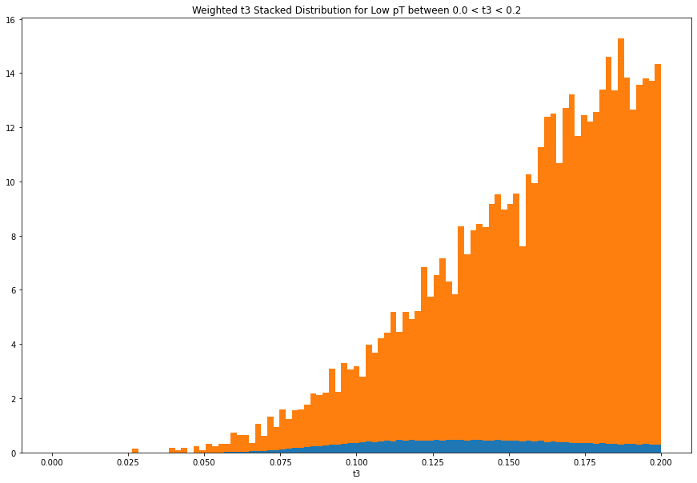

```
N_Higgs = 58.749000000058
N_QCD = 1209.4000000000963
N_Higgs/sqrt(N_QCD) = 1.689333897390707
Poisson Significance = 1.6906150725333684
```

```python
result = makeCuts(0,0.4,0.2,feature)
limit = 0+(0.2*result[2])
x = np.linspace(limit,limit+0.2,100)
plt.hist(stacked,x,stacked=True,density=True,weights=stacked_weight)
plt.title('Weighted ' + feature + ' Stacked Distribution for Low pT between '
          + str(limit) + ' < ' + feature + ' < ' + str(limit+0.2))
plt.xlabel(feature)
plt.show()
poiSig = stats.norm.ppf(stats.poisson.cdf(np.sum(result[0]),result[0][1]))
print('N_Higgs = ' + str(result[0][0]))
print('N_QCD = ' + str(result[0][1]))
print('N_Higgs/sqrt(N_QCD) = ' + str(result[0][0]/math.sqrt(result[0][1])))
print('Poisson Significance = ' + str(poiSig))
```

## T21 Ratio

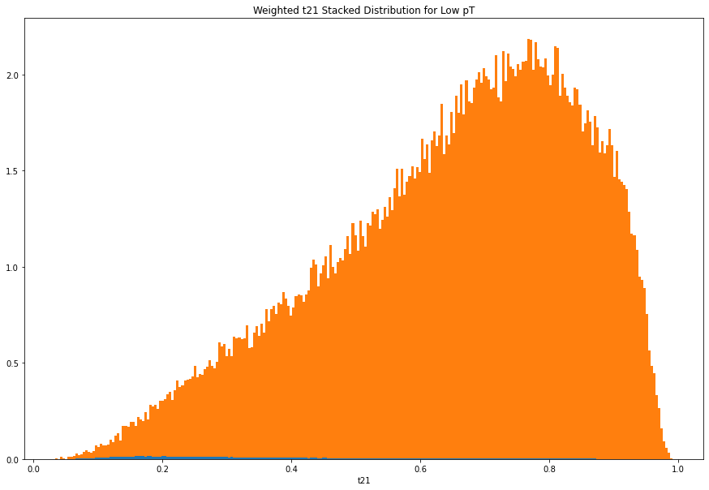

```
N_Higgs = 100.0000000001471
N_QCD = 19999.99999998956
N_Higgs/sqrt(N_QCD) = 0.7071067811877723
Poisson Significance = 0.7041666186913429
```

```python
feature = 't21'
counts = sig(feature,[])
stacked = [higgs[feature],qcd[feature]]
poiSig = stats.norm.ppf(stats.poisson.cdf(np.sum(counts),counts[1]))
plt.hist(stacked,250,stacked=True,density=True,weights=stacked_weight)
plt.title('Weighted ' + feature + ' Stacked Distribution for Low pT')
plt.xlabel(feature)
plt.show()
print('N_Higgs = ' + str(counts[0]))
print('N_QCD = ' + str(counts[1]))
print('N_Higgs/sqrt(N_QCD) = ' + str(counts[0]/math.sqrt(counts[1])))
print('Poisson Significance = ' + str(poiSig))
```

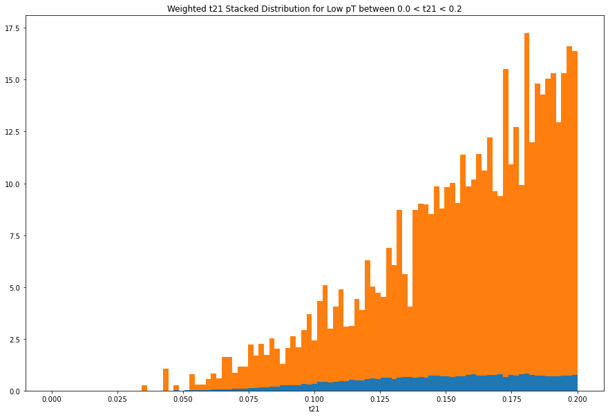

```
N_Higgs = 27.330999999990134
N_QCD = 352.6000000000133
N_Higgs/sqrt(N_QCD) = 1.4555072337260666
Poisson Significance = 1.4236643663098707
```

```python
result = makeCuts(0,0.4,0.2,feature)
limit = 0+(0.2*result[2])
x = np.linspace(limit,limit+0.2,100)
plt.hist(stacked,x,stacked=True,density=True,weights=stacked_weight)
plt.title('Weighted ' + feature + ' Stacked Distribution for Low pT between '
          + str(limit) + ' < ' + feature + ' < ' + str(limit+0.2))
plt.xlabel(feature)
plt.show()
poiSig = stats.norm.ppf(stats.poisson.cdf(np.sum(result[0]),result[0][1]))
print('N_Higgs = ' + str(result[0][0]))
print('N_QCD = ' + str(result[0][1]))
print('N_Higgs/sqrt(N_QCD) = ' + str(result[0][0]/math.sqrt(result[0][1])))
print('Poisson Significance = ' + str(poiSig))
```

## T32 Ratio

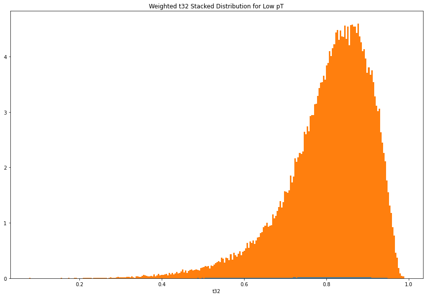

```
N_Higgs = 100.0000000001471
N_QCD = 19999.99999998956
N_Higgs/sqrt(N_QCD) = 0.7071067811877723
Poisson Significance = 0.7041666186913429
```

```python
feature = 't32'
counts = sig(feature,[])
stacked = [higgs[feature],qcd[feature]]
poiSig = stats.norm.ppf(stats.poisson.cdf(np.sum(counts),counts[1]))
plt.hist(stacked,250,stacked=True,density=True,weights=stacked_weight)
plt.title('Weighted ' + feature + ' Stacked Distribution for Low pT')
plt.xlabel(feature)
plt.show()
print('N_Higgs = ' + str(counts[0]))
print('N_QCD = ' + str(counts[1]))
print('N_Higgs/sqrt(N_QCD) = ' + str(counts[0]/math.sqrt(counts[1])))
print('Poisson Significance = ' + str(poiSig))
```

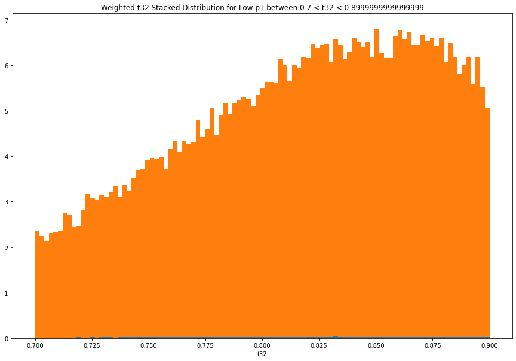

```
N_Higgs = 64.4020000000702
N_QCD = 13808.999999993164
N_Higgs/sqrt(N_QCD) = 0.5480475489109201
Poisson Significance = 0.5498722545650944
```

```python
result = makeCuts(0.5,0.9,0.2,feature)
limit = 0.5+(0.2*result[2])
x = np.linspace(limit,limit+0.2,100)
plt.hist(stacked,x,stacked=True,density=True,weights=stacked_weight)
plt.title('Weighted ' + feature + ' Stacked Distribution for Low pT between '
          + str(limit) + ' < ' + feature + ' < ' + str(limit+0.2))
plt.xlabel(feature)
plt.show()
poiSig = stats.norm.ppf(stats.poisson.cdf(np.sum(result[0]),result[0][1]))
print('N_Higgs = ' + str(result[0][0]))
print('N_QCD = ' + str(result[0][1]))
print('N_Higgs/sqrt(N_QCD) = ' + str(result[0][0]/math.sqrt(result[0][1])))
print('Poisson Significance = ' + str(poiSig))
```

## KtDeltaR

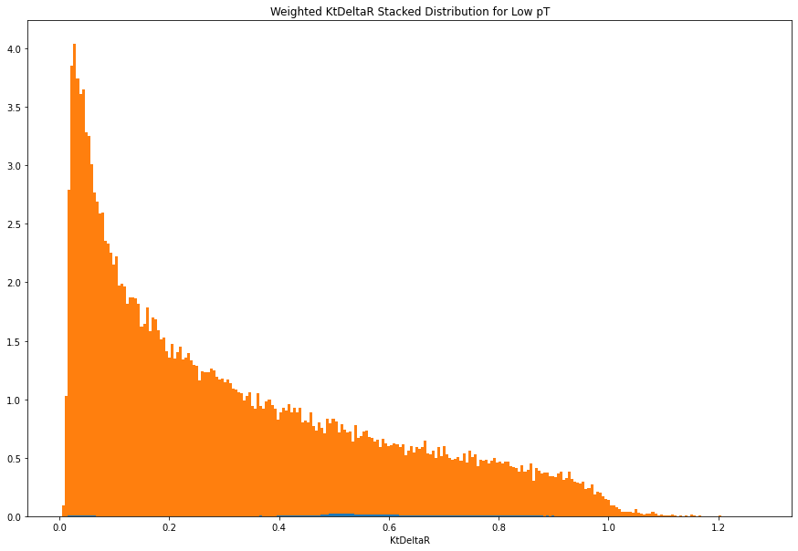

```
N_Higgs = 100.0000000001471
N_QCD = 19999.99999998956
N_Higgs/sqrt(N_QCD) = 0.7071067811877723
Poisson Significance = 0.7041666186913429
```

```python
feature = 'KtDeltaR'
counts = sig(feature,[])
stacked = [higgs[feature],qcd[feature]]
poiSig = stats.norm.ppf(stats.poisson.cdf(np.sum(counts),counts[1]))
plt.hist(stacked,250,stacked=True,density=True,weights=stacked_weight)
plt.title('Weighted ' + feature + ' Stacked Distribution for Low pT')
plt.xlabel(feature)
plt.show()
print('N_Higgs = ' + str(counts[0]))
print('N_QCD = ' + str(counts[1]))
print('N_Higgs/sqrt(N_QCD) = ' + str(counts[0]/math.sqrt(counts[1])))
print('Poisson Significance = ' + str(poiSig))
```

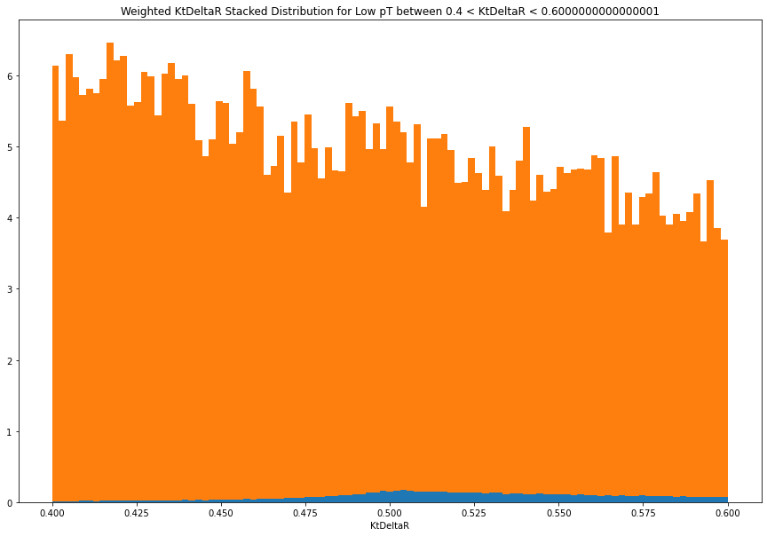

```
N_Higgs = 49.13700000003723
N_QCD = 3039.59999999943
N_Higgs/sqrt(N_QCD) = 0.8912517994578657
Poisson Significance = 0.887605789889544
```

```python
result = makeCuts(0.2,0.8,0.2,feature)
limit = 0.2+(0.2*result[2])
x = np.linspace(limit,limit+0.2,100)
plt.hist(stacked,x,stacked=True,density=True,weights=stacked_weight)
plt.title('Weighted ' + feature + ' Stacked Distribution for Low pT between '
          + str(limit) + ' < ' + feature + ' < ' + str(limit+0.2))
plt.xlabel(feature)
plt.show()
poiSig = stats.norm.ppf(stats.poisson.cdf(np.sum(result[0]),result[0][1]))
print('N_Higgs = ' + str(result[0][0]))
print('N_QCD = ' + str(result[0][1]))
print('N_Higgs/sqrt(N_QCD) = ' + str(result[0][0]/math.sqrt(result[0][1])))
print('Poisson Significance = ' + str(poiSig))
```

## Single Feature Reflection

Overall, no other feature was able to be as discriminative as mass. It resulted in by far the best significance. The next three contenders, T2, T3 and T21 had relatively the same increase in significance. I am going to use these feature and see if I can optimize my selection even further by combining multiple cuts.

## Multiple Features

```python
def twoCutSig(features,cuts):
    dist = []
    higgs_cut = []
    qcd_cut = []
    totalArea = 0
    for i in range(100000):
        if higgs[features[0]][i] >= cuts[0][0] and higgs[features[0]][i] < cuts[0][1]:
            if higgs[features[1]][i] >= cuts[1][0] and higgs[features[1]][i] < cuts[1][1]:
                dist.append([higgs[features[1]][i], 'h'])
                higgs_cut.append(higgs[features[1]][i])
                totalArea += 100/20100
        if qcd[features[0]][i] >= cuts[0][0] and qcd[features[0]][i] < cuts[0][1]:
            if qcd[features[1]][i] >= cuts[1][0] and qcd[features[1]][i] < cuts[1][1]:
                dist.append([qcd[features[1]][i], 'q'])
                qcd_cut.append(qcd[features[1]][i])
                totalArea += 20000/20100
    dist.sort()
    searchArea = 0
    for i in range(len(dist)):
        weighted = 0
        if dist[i][1] == 'h':
            weighted = 100/20100
        else:
            weighted = 20000/20100
        searchArea += weighted/totalArea
    counts = [0, 0]
    for i in range(len(dist)):
        if dist[i][1] == 'h':
            counts[0] += 100/20100
        else:
            counts[1] += 20000/20100
    return [i * 20100/100000 for i in counts], higgs_cut, qcd_cut
```

## Mass then T21

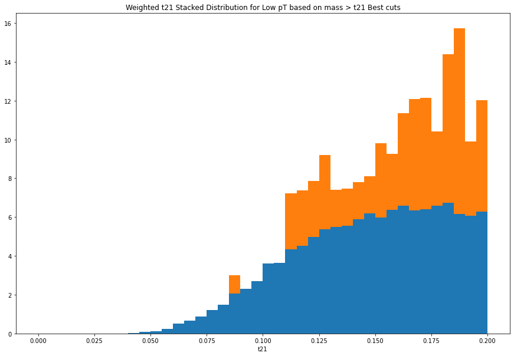

```
N_Higgs = 26.210999999987717
N_QCD = 15.600000000000033
N_Higgs/sqrt(N_QCD) = 6.636227887654379
Poisson Significance = 5.458128727807427
```

```python
counts, higgs_cut, qcd_cut = twoCutSig(['mass', 't21'], [[120,130],[0,0.2]])
stack = [higgs_cut,qcd_cut]
stack_weight = [np.ones(len(stack[0]))*100,np.ones(len(stack[1]))*20000]
x = np.linspace(0,0.2,41)
plt.hist(stack,x,stacked=True,density=True,weights=stack_weight)
plt.title('Weighted t21 Stacked Distribution for Low pT based on mass > t21 Best cuts')
plt.xlabel('t21')
plt.show()
poiSig = stats.norm.ppf(stats.poisson.cdf(np.sum(counts),counts[1]))
print('N_Higgs = ' + str(counts[0]))
print('N_QCD = ' + str(counts[1]))
print('N_Higgs/sqrt(N_QCD) = ' + str(counts[0]/math.sqrt(counts[1])))
print('Poisson Significance = ' + str(poiSig))
```

## T21 then Mass

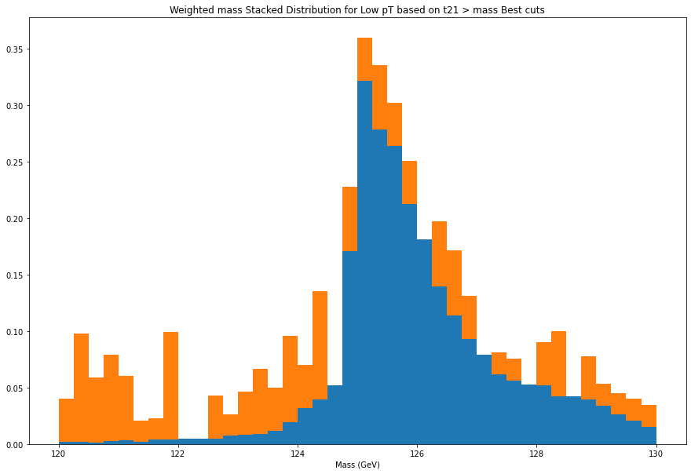

```
N_Higgs = 26.210999999987717
N_QCD = 15.600000000000033
N_Higgs/sqrt(N_QCD) = 6.636227887654379
Poisson Significance = 5.458128727807427
```

```python
counts, higgs_cut, qcd_cut = twoCutSig(['t21', 'mass'], [[0,0.2],[120,130]])
stack = [higgs_cut,qcd_cut]
stack_weight = [np.ones(len(stack[0]))*100,np.ones(len(stack[1]))*20000]
x = np.linspace(120,130,41)
plt.hist(stack,x,stacked=True,density=True,weights=stack_weight)
plt.title('Weighted mass Stacked Distribution for Low pT based on t21 > mass Best cuts')
plt.xlabel('Mass (GeV)')
plt.show()
poiSig = stats.norm.ppf(stats.poisson.cdf(np.sum(counts),counts[1]))
print('N_Higgs = ' + str(counts[0]))
print('N_QCD = ' + str(counts[1]))
print('N_Higgs/sqrt(N_QCD) = ' + str(counts[0]/math.sqrt(counts[1])))
print('Poisson Significance = ' + str(poiSig))
```

After two cuts, the significance shot way up to an above 5-sigma value. There also doesn't seem to be any change in the order of cutting the same two features.

## T3 then Mass

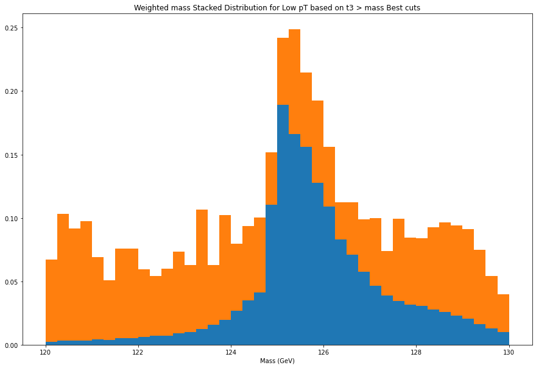

```
N_Higgs = 54.65800000004916
N_QCD = 81.19999999999946
N_Higgs/sqrt(N_QCD) = 6.06562729914113
Poisson Significance = 5.509364423553984
```

```python
counts, higgs_cut, qcd_cut = twoCutSig(['t3', 'mass'], [[0,0.2],[120,130]])
stack = [higgs_cut,qcd_cut]
stack_weight = [np.ones(len(stack[0]))*100,np.ones(len(stack[1]))*20000]
x = np.linspace(120,130,41)
plt.hist(stack,x,stacked=True,density=True,weights=stack_weight)
plt.title('Weighted mass Stacked Distribution for Low pT based on t3 > mass Best cuts')
plt.xlabel('Mass (GeV)')
plt.show()
poiSig = stats.norm.ppf(stats.poisson.cdf(np.sum(counts),counts[1]))
print('N_Higgs = ' + str(counts[0]))
print('N_QCD = ' + str(counts[1]))
print('N_Higgs/sqrt(N_QCD) = ' + str(counts[0]/math.sqrt(counts[1])))
print('Poisson Significance = ' + str(poiSig))
```

## T2 then Mass

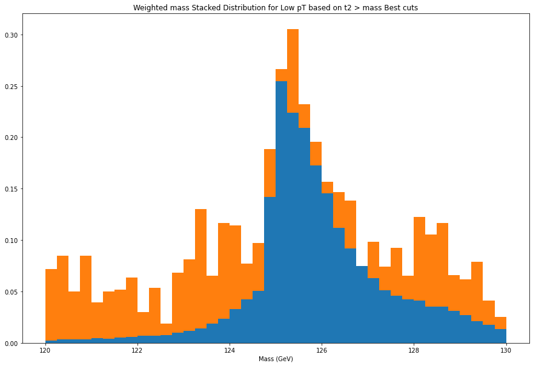

```
N_Higgs = 36.2510000000094
N_QCD = 32.59999999999999
N_Higgs/sqrt(N_QCD) = 6.349085729555706
Poisson Significance = 5.495906091865776
```

```python
counts, higgs_cut, qcd_cut = twoCutSig(['t2', 'mass'], [[0,0.2],[120,130]])
stack = [higgs_cut,qcd_cut]
stack_weight = [np.ones(len(stack[0]))*100,np.ones(len(stack[1]))*20000]
x = np.linspace(120,130,41)
plt.hist(stack,x,stacked=True,density=True,weights=stack_weight)
plt.title('Weighted mass Stacked Distribution for Low pT based on t2 > mass Best cuts')
plt.xlabel('Mass (GeV)')
plt.show()
poiSig = stats.norm.ppf(stats.poisson.cdf(np.sum(counts),counts[1]))
print('N_Higgs = ' + str(counts[0]))
print('N_QCD = ' + str(counts[1]))
print('N_Higgs/sqrt(N_QCD) = ' + str(counts[0]/math.sqrt(counts[1])))
print('Poisson Significance = ' + str(poiSig))
```

## Pseudo-experiment Data

```python
import pandas as pd

highL = pd.read_hdf('E:/EECS/PHYS434/Project/data_highLumi_pt_250_500.h5')
lowL = pd.read_hdf('E:/EECS/PHYS434/Project/data_lowLumi_pt_250_500.h5')
```

```python
def pseudoTwoCut(data,features,cuts):
    dist = []
    for i in range(len(data[features[0]])):
        if data[features[0]][i] >= cuts[0][0] and data[features[0]][i] < cuts[0][1]:
            if data[features[1]][i] >= cuts[1][0] and data[features[1]][i] < cuts[1][1]:
                dist.append(data[features[1]][i])
    return dist
```

## High Luminosity

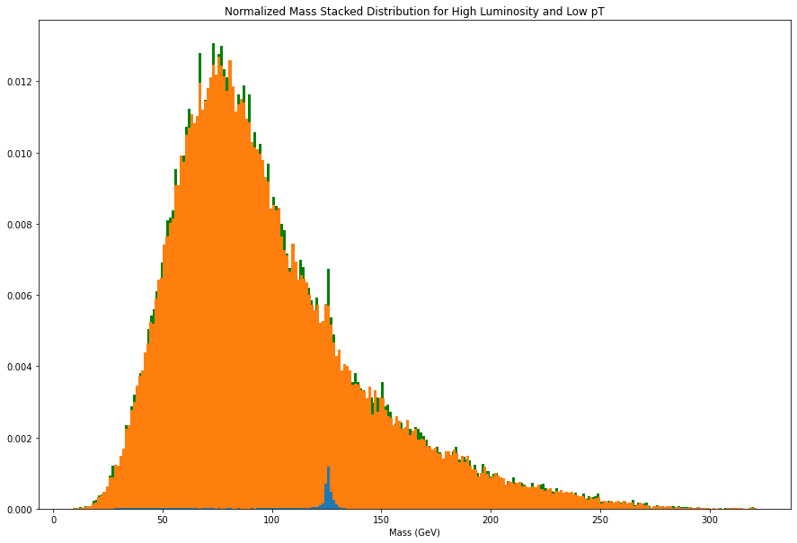

```python
stacked = [higgs['mass'],qcd['mass']]
stacked_weight = [np.ones(100000)*100,np.ones(100000)*20000]
plt.hist(highL['mass'],250,density=True,color='green')
plt.hist(stacked,250,stacked=True,density=True,weights=stacked_weight)
plt.title('Normalized Mass Stacked Distribution for High Luminosity and Low pT')
plt.xlabel('Mass (GeV)')
plt.show()
```

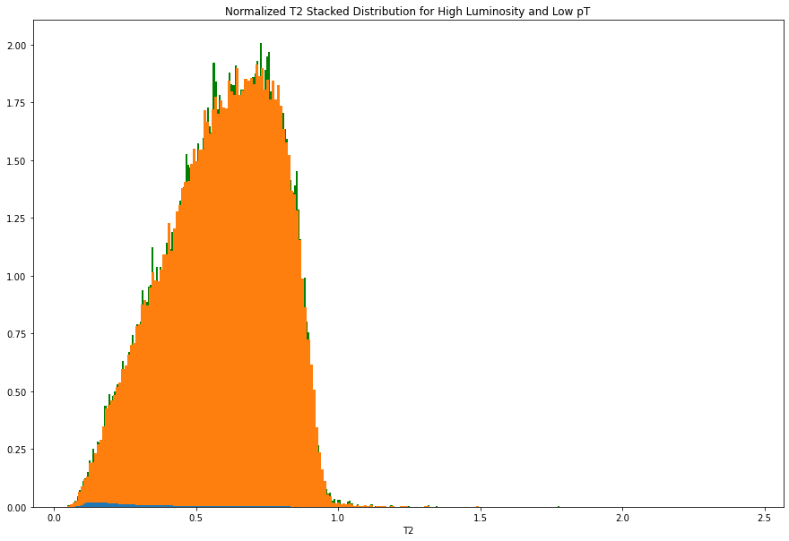

```python
stacked = [higgs['t2'],qcd['t2']]
stacked_weight = [np.ones(100000)*100,np.ones(100000)*20000]
plt.hist(highL['t2'],250,density=True,color='green')
plt.hist(stacked,250,stacked=True,density=True,weights=stacked_weight)
plt.title('Normalized T2 Stacked Distribution for High Luminosity and Low pT')
plt.xlabel('T2')
plt.show()
```

The green area in the plots represent the pseudo-experiment data. In both cases, the shape basically resembles that of the QCD distribution, though we can see noticable noisy peaks throughout.

```python
counts, higgs_cut, qcd_cut = twoCutSig(['t2', 'mass'], [[0,0.2],[120,130]])
pseudoCut = pseudoTwoCut(highL,['t2', 'mass'],[[0,0.2],[120,130]])
```

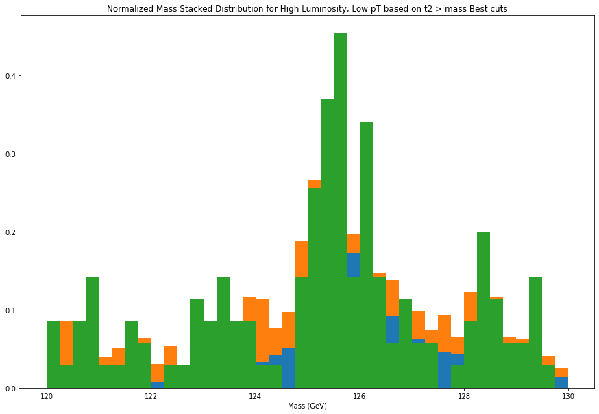

```
Jet count after event selection = 141
Poisson Significance = 3.0330115138936504
```

```python
stack = [higgs_cut,qcd_cut]
stack_weight = [np.ones(len(stack[0]))*100,np.ones(len(stack[1]))*20000]
x = np.linspace(120,130,41)
N_bkgd = 0
for i in range(len(highL['mass'])):
    if highL['mass'][i] >= 120 and highL['mass'][i] < 130:
        N_bkgd += 1
plt.hist(stack,x,stacked=True,density=True,weights=stack_weight)
plt.hist(pseudoCut,x,density=True)
plt.title('Normalized Mass Stacked Distribution for High Luminosity, Low pT based on t2 > mass Best cuts')
plt.xlabel('Mass (GeV)')
plt.show()
poiSig = stats.norm.ppf(stats.poisson.cdf(len(pseudoCut)+N_bkgd,N_bkgd))
print('Jet count after event selection = ' + str(len(pseudoCut)))
print('Poisson Significance = ' + str(poiSig))
```

After the event selection, I managed to find 141 jets in this cut. To find the significance, I counted the number of background high luminosity data in the 120 to 130 mass slice to serve as my background mean, N_bkgd. Then, my N_observed would be the jet count resulting from the event selection + N_bkgd. The resulting significance, however, is lower than the one derived from the training data.

## Low Luminosity

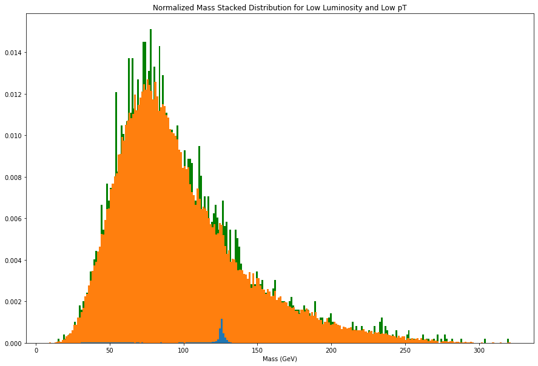

```python
stacked = [higgs['mass'],qcd['mass']]
stacked_weight = [np.ones(100000)*100,np.ones(100000)*20000]
plt.hist(lowL['mass'],250,density=True,color='green')
plt.hist(stacked,250,stacked=True,density=True,weights=stacked_weight)
plt.title('Normalized Mass Stacked Distribution for Low Luminosity and Low pT')
plt.xlabel('Mass (GeV)')
plt.show()
```

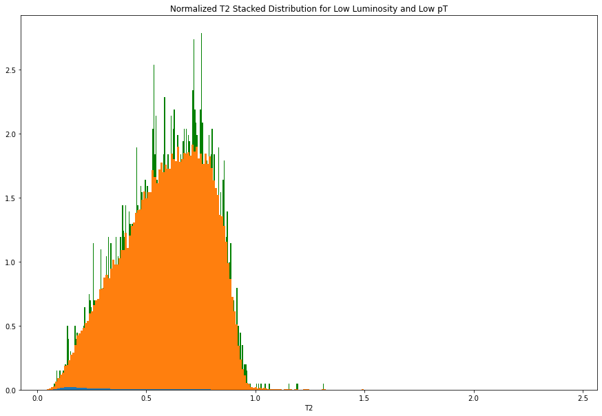

```python
stacked = [higgs['t2'],qcd['t2']]
stacked_weight = [np.ones(100000)*100,np.ones(100000)*20000]
plt.hist(lowL['t2'],250,density=True,color='green')
plt.hist(stacked,250,stacked=True,density=True,weights=stacked_weight)
plt.title('Normalized T2 Stacked Distribution for Low Luminosity and Low pT')
plt.xlabel('T2')
plt.show()
```

Again, the pseudo-experiment distribution resembles that of the QCD distribution, but the noisy peaks are way higher and noticable compared to the high luminosity data.

```python
counts, higgs_cut, qcd_cut = twoCutSig(['t2', 'mass'], [[0,0.2],[120,130]])
pseudoCut = pseudoTwoCut(lowL,['t2', 'mass'],[[0,0.2],[120,130]])
```

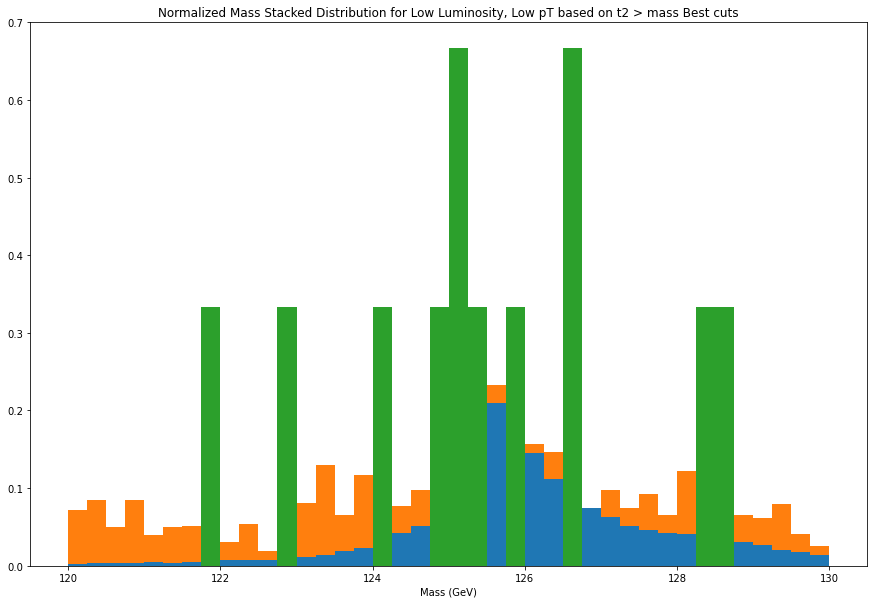

```
Jet count after event selection = 12
Poisson Significance = 0.8073862044519212
```

```python
stack = [higgs_cut,qcd_cut]
stack_weight = [np.ones(len(stack[0]))*100,np.ones(len(stack[1]))*20000]
x = np.linspace(120,130,41)
N_bkgd = 0
for i in range(len(lowL['mass'])):
    if lowL['mass'][i] >= 120 and lowL['mass'][i] < 130:
        N_bkgd += 1
plt.hist(stack,x,stacked=True,density=True,weights=stack_weight)
plt.hist(pseudoCut,x,density=True)
plt.title('Normalized Mass Stacked Distribution for Low Luminosity, Low pT based on t2 > mass Best cuts')
plt.xlabel('Mass (GeV)')
plt.show()
poiSig = stats.norm.ppf(stats.poisson.cdf(len(pseudoCut)+N_bkgd,N_bkgd))
print('Jet count after event selection = ' + str(len(pseudoCut)))
print('Poisson Significance = ' + str(poiSig))
```